# R-Week10 - Time Varying Conditional Volatility

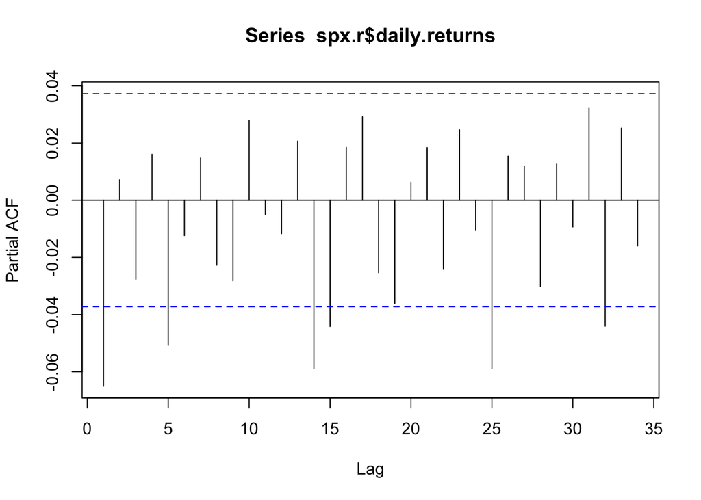

```r
pacf(spx.r$daily.returns)
```

From the plot of the data, we can clearly discern the presence of volatility clustering. That is, there are distinct periods of high volatility followed by periods of relatively low volatility. Turning our attention to the sample ACF and PACF we notice that there are some auto correlations and partial auto correlations that are individually significant. However, they are quite small in magnitude and are likely due to some market/trading specific phenomena such as day of week effects. We can certainly spend some time trying to account for these dependencies by trying out a range of ARMA specifications, but that’s not the focus of what we are trying to do. So let’s use **auto.arima()** to pick a model for the mean equation:

```r
mean.eq <- auto.arima(spx.r$daily.returns, allowmean = FALSE)
mean.eq
```

```
## Series: spx.r$daily.returns
## ARIMA(4,0,3) with zero mean
##
## Coefficients:
##           ar1     ar2     ar3     ar4     ma1      ma2      ma3
##       -0.5236  0.2722  0.8669  0.0390  0.4639  -0.2959  -0.8781
## s.e.   0.1020  0.1394  0.1097  0.0225  0.0999   0.1278   0.0938
##
## sigma^2 = 1.048:  log likelihood = -3985.99
## AIC=7987.98   AICc=7988.04   BIC=8035.38
```

Then, let’s have a look at the residuals and squared residuals from the mean equation:

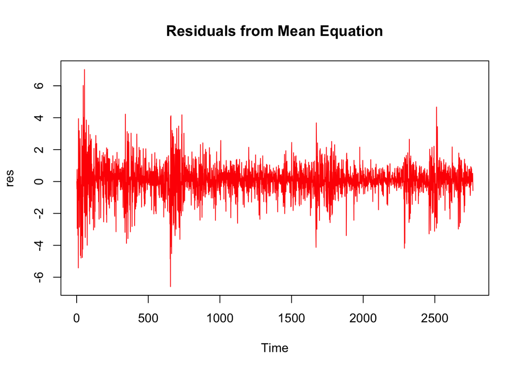

```r
res <- resid(mean.eq)

res.sq <- res^2

plot(res, col = "red", main = "Residuals from Mean Equation")
```

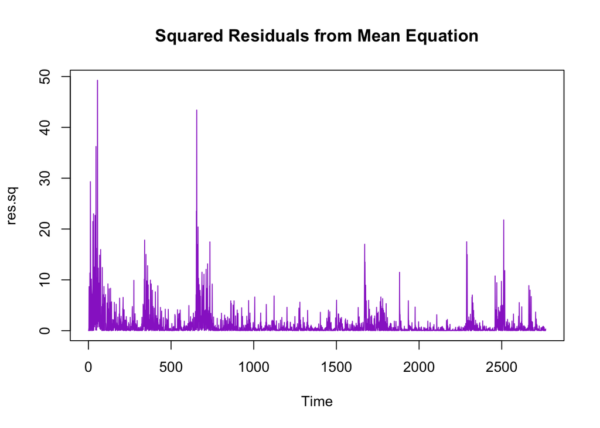

```r
plot(res.sq, col = "darkorchid", main = "Squared Residuals from Mean Equation")
```

Looking at the sample autocorrelations and partial autocorrelations of the residuals from the mean equation, we can see that not much dependence remains. Again there are some statistically significant lags but let’s not worry too much about them.

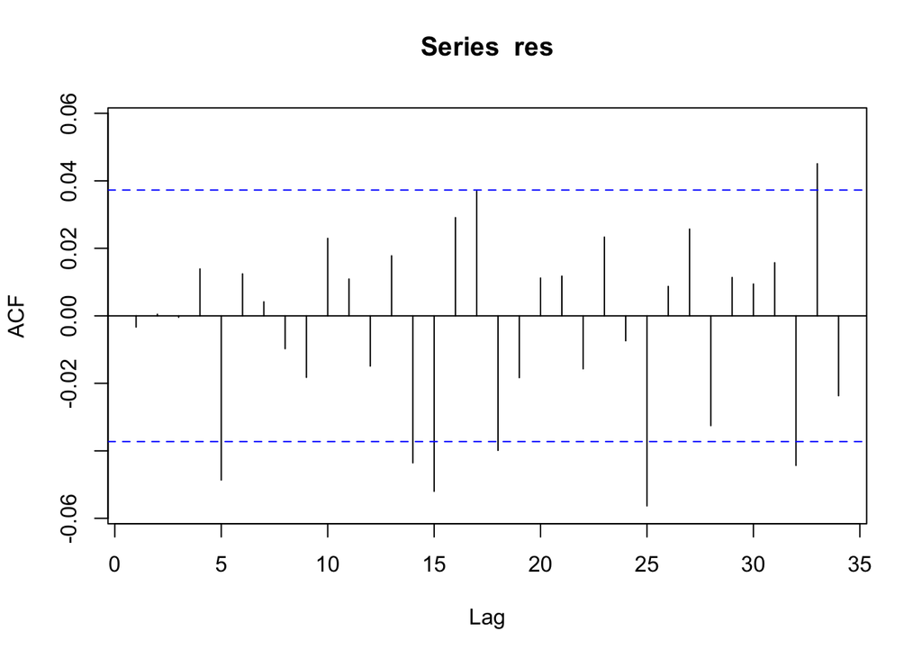

```r
Acf(res)
```

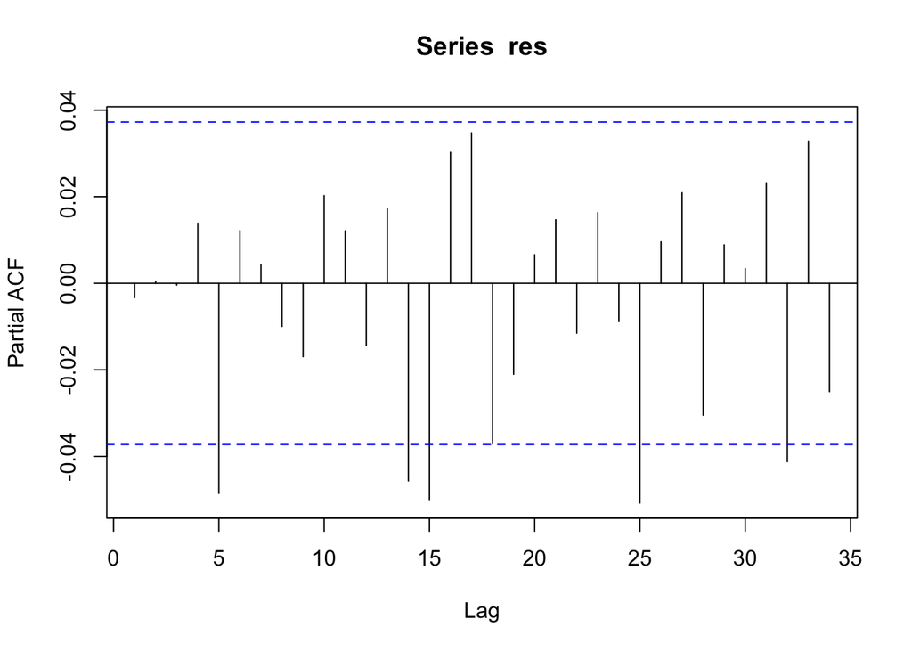

```r
pacf(res)
```

Looking at the sample autocorrelations and partial autocorrelations of the squared residuals we can see a much stronger dependence structure that resembles an AR!

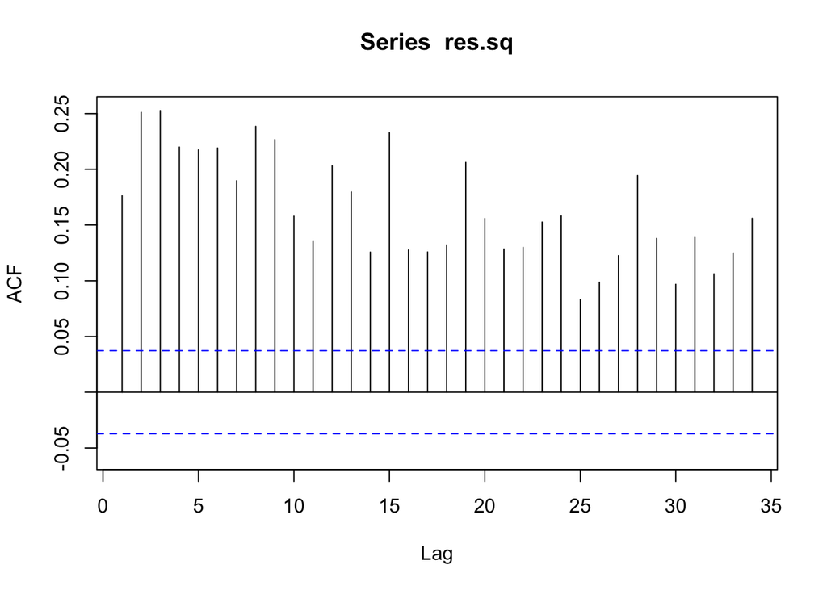

```r
Acf(res.sq)
```

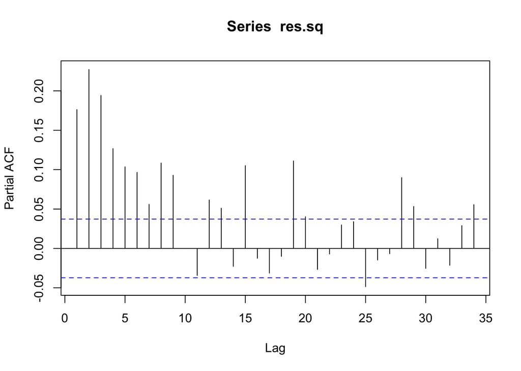

```r
pacf(res.sq)
```

Performing our portmanteau tests on the squared residuals we can conclude that there exist ARCH effects!

```r
T <- length(res.sq)

m <- ceiling(sqrt(T))

Box.test(res.sq, lag = m, type = "Box-Pierce")
```

```
##
##  Box-Pierce test
##
## data:  res.sq
## X-squared = 3266, df = 53, p-value < 2.2e-16
```

```r
Box.test(res.sq, lag = m, type = "Ljung-Box")
```

```
##
##  Box-Ljung test
##
## data:  res.sq
## X-squared = 3289.8, df = 53, p-value < 2.2e-16
```

## Estimating an ARCH Model

From the sample PACF plot, we can see that there are some significant partial autocorrelations at rather long lags! So let’s try a range of ARCH orders from ARCH(1) to ARCH(35) and see which one yields the lowest information criteria:

```r
z = 35

prefix.arch <- "arch"
suffix.arch <- seq(1,z)

arch.label <- paste(prefix.arch, suffix.arch, sep = "" )

arch.info <- data.frame(row.names = arch.label, matrix(NA,z,2))

colnames(arch.info) <- c("aic","bic")

T <- length(res)

for(i in 1:z){
archmod <- garch(res, order = c(0,i))
arch.info[i,1] <- AIC(archmod)
arch.info[i,2] <- AIC(archmod, k = log(T-i-1))
}
```

Then, we simply pick the ARCH specification that yields the minimum information criterion. From the code below we can see that the AIC will choose an ARCH(19) while the BIC will choose an ARCH(10)

```r
akaike.choice <- rownames(arch.info)[which.min(arch.info[,1])]
bayes.choice <- rownames(arch.info)[which.min(arch.info[,2])]

akaike.choice
```

```
## [1] "arch19"
```

```r
bayes.choice
```

```
## [1] "arch10"
```

Let’s go with the BIC and use the ARCH(10) as our chosen model. The residuals generated from this model will be the standardised residuals presented in the lecture:

$$u_t = \frac{e_t}{\hat{\sigma}_t}$$
Notice now that the standardised residuals generated from the ARCH model exhibits much less volatility clustering!

```r
archmod <- garch(res, order = c(0,10))
```

```
##
##  ***** ESTIMATION WITH ANALYTICAL GRADIENT *****
##
##
##      I     INITIAL X(I)        D(I)
##
##      1     5.210093e-01     1.000e+00
##      2     5.000000e-02     1.000e+00
##      3     5.000000e-02     1.000e+00
##      4     5.000000e-02     1.000e+00
##      5     5.000000e-02     1.000e+00
##      6     5.000000e-02     1.000e+00
##      7     5.000000e-02     1.000e+00
##      8     5.000000e-02     1.000e+00
##      9     5.000000e-02     1.000e+00
```

[output cut: 60 more lines]

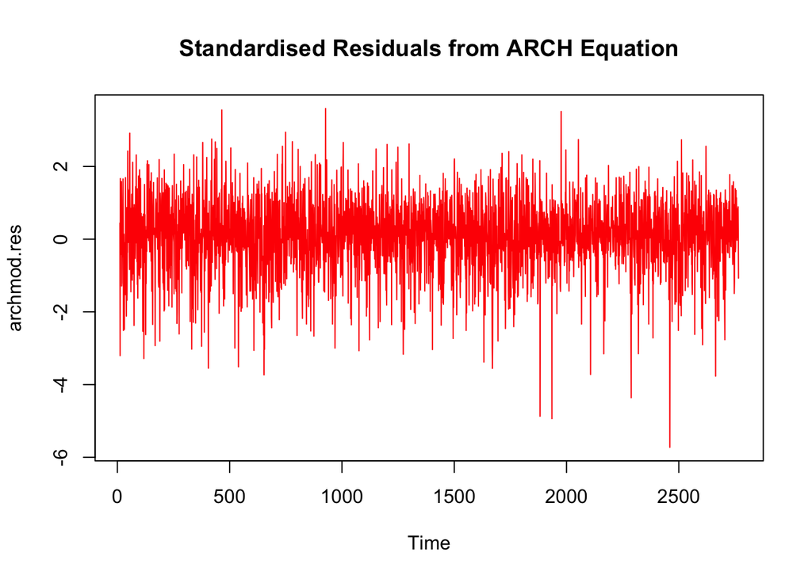

```r
archmod.res <- archmod$residuals

archmod.res <- na.omit(archmod.res)

plot(archmod.res, col = "red", main = "Standardised Residuals from ARCH Equation", type = "l")
```

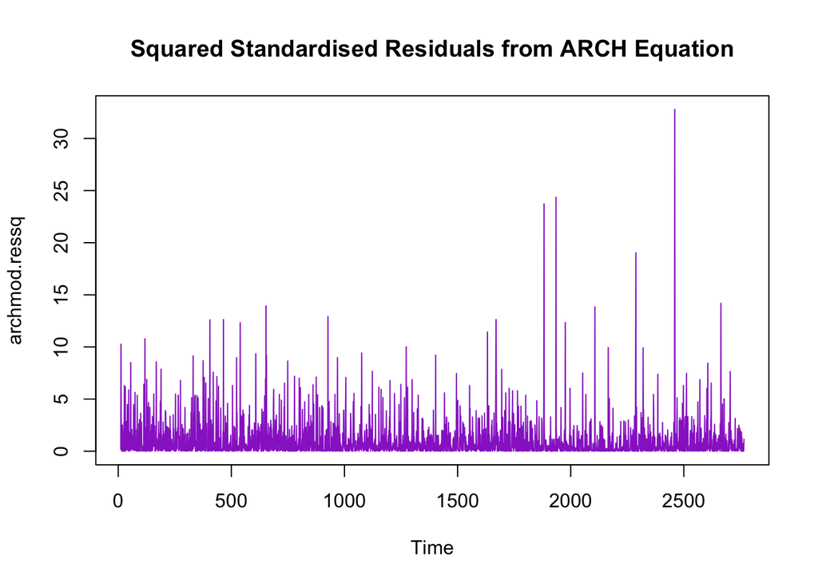

```r
archmod.ressq <- archmod.res^2

plot(archmod.ressq, col = "darkorchid", main = "Squared Standardised Residuals from ARCH Equation", type = "l")
```

When we perform our portmanteau tests on the squared standardised residuals we can see that the dependence that was once present has been eliminated.

```r
Box.test(archmod.ressq, lag = m, type = "Box-Pierce")
```

```
##
##  Box-Pierce test
##
## data:  archmod.ressq
## X-squared = 34.428, df = 53, p-value = 0.9775
```

```r
Box.test(archmod.ressq, lag = m, type = "Ljung-Box")
```

```
##
##  Box-Ljung test
##
## data:  archmod.ressq
## X-squared = 34.827, df = 53, p-value = 0.9746
```

## Estimating a GARCH Model

As discussed in the lecture, ARCH models typically require a lot of lags in order to account for the dependence in the squared residuals. This is due to the restrictions placed on the parameters of the model.

GARCH models allow us to account for the same amount of dependence but with much less terms! Let’s try fitting a GARCH(1,1) to the same set of residuals from our conditional mean equation for the S&P500:

```r
garchmod <- garch(res, order = c(1,1))
```

```
##
##  ***** ESTIMATION WITH ANALYTICAL GRADIENT *****
##
##
##      I     INITIAL X(I)        D(I)
##
##      1     9.378167e-01     1.000e+00
##      2     5.000000e-02     1.000e+00
##      3     5.000000e-02     1.000e+00
##
##     IT   NF      F         RELDF    PRELDF    RELDX   STPPAR   D*STEP   NPRELDF
##      0    1  1.391e+03
##      1    3  1.369e+03  1.63e-02  2.08e-01  2.5e-01  1.3e+03  4.6e-01  1.40e+02
##      2    4  1.334e+03  2.52e-02  4.85e-02  1.4e-01  2.8e+00  2.3e-01  3.86e+01
##      3    5  1.244e+03  6.78e-02  7.97e-02  1.5e-01  2.0e+00  2.3e-01  1.21e+02
```

[output cut: 43 more lines]

```r
garchmod.res <- garchmod$residuals

garchmod.res <- na.omit(garchmod.res)

garchmod.ressq <- garchmod.res^2
```

Looking at the standardised residuals from the GARCH(1,1) we can see that they are extremely similar to the ones produced by the ARCH(10) model:

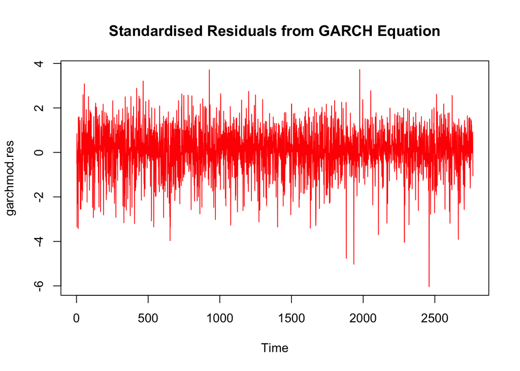

```r
plot(garchmod.res, col = "red", main = "Standardised Residuals from GARCH Equation", type = "l")
```

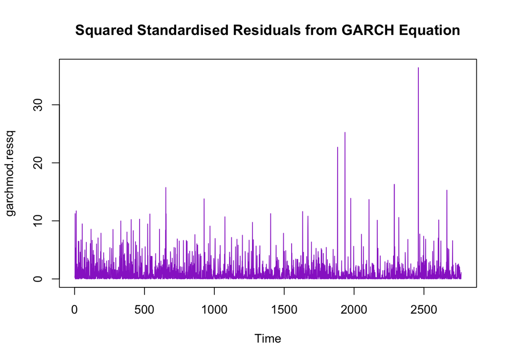

```r
plot(garchmod.ressq, col ="darkorchid", main = "Squared Standardised Residuals from GARCH Equation", type = "l")
```

When we perform our portmanteau tests on the squared standardised residuals from our GARCH(1,1) model, we can see again that the dependence that was once present has been eliminated.

```r
Box.test(garchmod.ressq, lag = m, type = "Box-Pierce")
```

```
##
##  Box-Pierce test
##
## data:  garchmod.ressq
## X-squared = 36.733, df = 53, p-value = 0.9566
```

```r
Box.test(garchmod.ressq, lag = m, type = "Ljung-Box")
```

```
##
##  Box-Ljung test
##
## data:  garchmod.ressq
## X-squared = 37.101, df = 53, p-value = 0.9522
```

Therefore our GARCH(1,1) model has managed to do the same job as the ARCH(10) but in a much more parsimonious fashion (i.e., with a lot less parameters!).

## Extensions of the GARCH Model

One potential shortcoming of the standard ARCH and GARCH specifications is the fact that positive and negative shocks are assumed to have the same effect on the conditional volatility. This may not be a suitable assumption to make especially for financial returns since it is a well observed fact that financial markets are much more volatile after negative shocks. Moreover, there are good theoretical reasons (e.g., the leverage effect) for why we should treat negative shocks differently to positive shocks.

Let’s now work with the weekly returns on the Australian All Ordinaries Index. Looking at the plot we can again clearly observe the presence of volatility clustering:

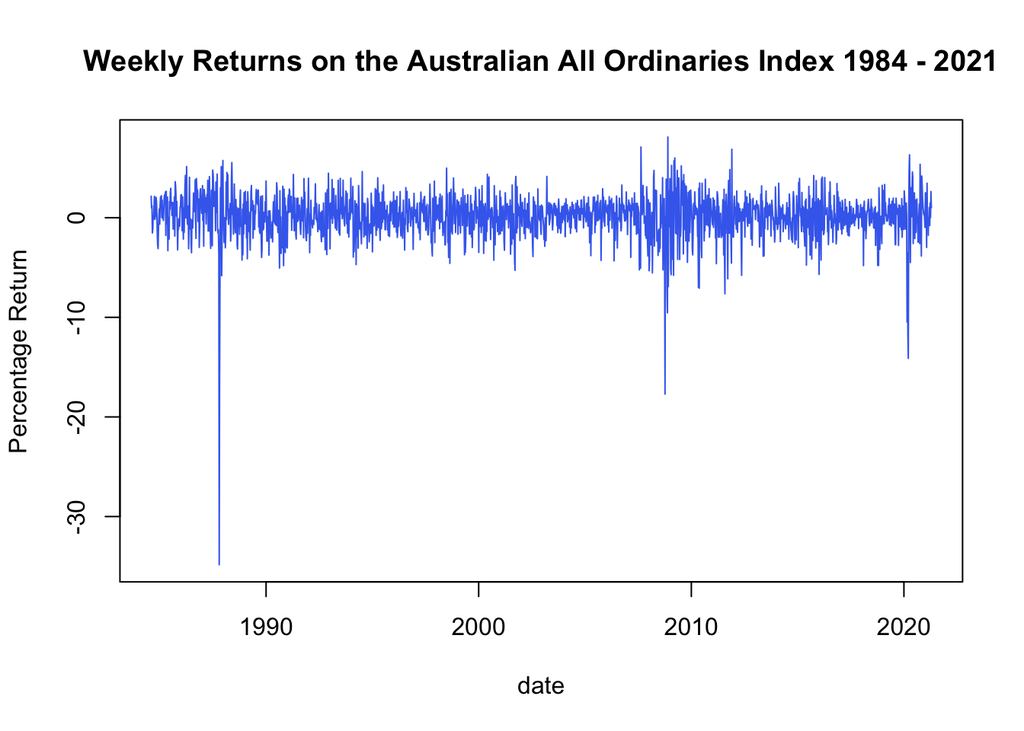

```r
aord = 100*diff(log(read.csv("AORD-weekly.csv")[,2]))

T = length(aord)

date = as.Date(read.csv("AORD-Weekly.csv")[,1])

date = date[-1]

plot(date,aord,
        main = "Weekly Returns on the Australian All Ordinaries Index 1984 - 2021",
        ylab = "Percentage Return",
        type = "l",
        col = "royalblue2",
        lwd = 1.0)
```

Again, let’s just use **auto.arima()** to pick the specification of our mean equation:

```r
auto.arima(aord)
```

```
## Series: aord
## ARIMA(2,0,0) with non-zero mean
##
## Coefficients:
##          ar1     ar2    mean
##       0.1090  0.0525  0.1213
## s.e.  0.0228  0.0228  0.0592
##
## sigma^2 = 4.735:  log likelihood = -4206.92
## AIC=8421.83   AICc=8421.85   BIC=8444.06
```

From the output above, we can see that the chosen model is an ARMA(2,0). In order to estimate asymmetric GARCH models, we will use the **rugarch** package:

```r
library(rugarch)
library(FinTS)
```

Estimating GARCH models using the **rugarch** package is slightly a bit more involved. First, we need to specify the model we want to estimate using the **ugarchspec()** function. As a first step we will estimate a standard GARCH(1,1) by setting *model = sGARCH* and *garch0rder = c(1,1)*. We store the specification details in the object **garch.mod**

```r
garch.mod = ugarchspec(mean.model = list(armaOrder = c(2, 0), include.mean = TRUE),
                       variance.model = list(model = "sGARCH", garchOrder = c(1,1)),
                       distribution.model = "norm")
```

Then, we proceed to use the specification details as an input into the **ugarchfit()** function which actually performs the estimation. We will store our estimation output in the object called **garch.fit**.

```r
garch.fit = ugarchfit(spec=garch.mod,
                      data=aord,
                      solver = "hybrid",
                      solver.control = list(ftol_rel=1e-11,xtol_rel=1e-11,maxeval=10000))
garch.fit
```

```
##
## *---------------------------------*
## *          GARCH Model Fit        *
## *---------------------------------*
##
## Conditional Variance Dynamics
## -----------------------------------
## GARCH Model  : sGARCH(1,1)
## Mean Model   : ARFIMA(2,0,0)
## Distribution : norm
##
## Optimal Parameters
## ------------------------------------
##         Estimate  Std. Error  t value Pr(>|t|)
## mu      0.236219    0.044667  5.28850 0.000000
## ar1     0.015859    0.026749  0.59288 0.553261
## ar2     0.032077    0.025821  1.24229 0.214131
## omega   0.327794    0.114687  2.85817 0.004261
## alpha1  0.221074    0.040618  5.44280 0.000000
## beta1   0.738819    0.054905 13.45625 0.000000
##
## Robust Standard Errors:
##         Estimate  Std. Error  t value Pr(>|t|)
## mu      0.236219    0.092756  2.54667 0.010876
## ar1     0.015859    0.037421  0.42379 0.671718
## ar2     0.032077    0.028969  1.10728 0.268174
## omega   0.327794    0.316777  1.03478 0.300772
## alpha1  0.221074    0.179816  1.22944 0.218905
## beta1   0.738819    0.184950  3.99470 0.000065
##
## LogLikelihood : -4006.339
##
## Information Criteria
## ------------------------------------
##
## Akaike       4.1882
## Bayes        4.2057
## Shibata      4.1882
## Hannan-Quinn 4.1947
##
```

[output cut: 43 more lines]

```
## Negative Sign Bias  1.2225 0.22167
## Positive Sign Bias  0.9023 0.36700
## Joint Effect        6.7599 0.07996   *
##
##
## Adjusted Pearson Goodness-of-Fit Test:
## ------------------------------------
##   group statistic p-value(g-1)
## 1    20     69.91    9.527e-08
## 2    30     78.34    2.020e-06
## 3    40     95.94    1.059e-06
## 4    50    108.84    1.955e-06
##
##
## Elapsed time : 0.192441
```

As we can see from above the **ugarchfit()** function produces much more detailed output compared to the standard **garch()** function. Moreover, we can generate diagnostic plots very easily using the **plot()** function. For instance:

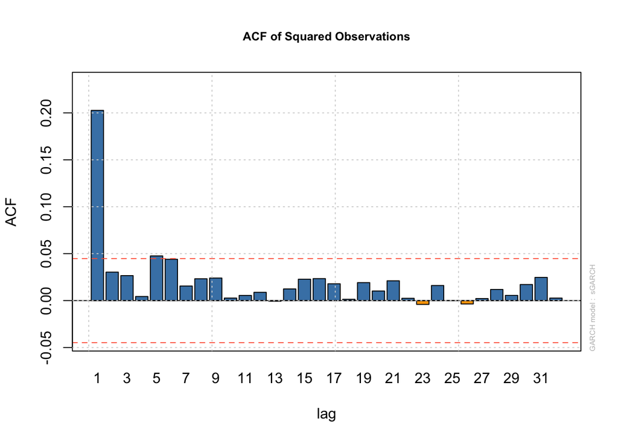

```r
plot(garch.fit, which = 5)
```

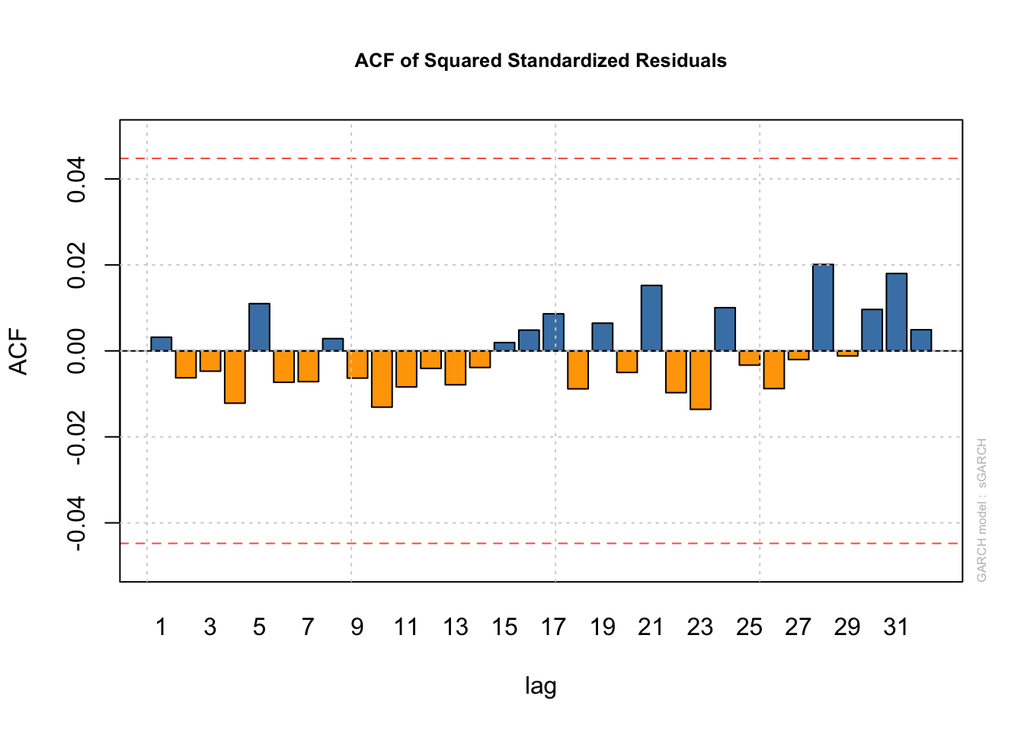

```r
plot(garch.fit, which = 11)
```

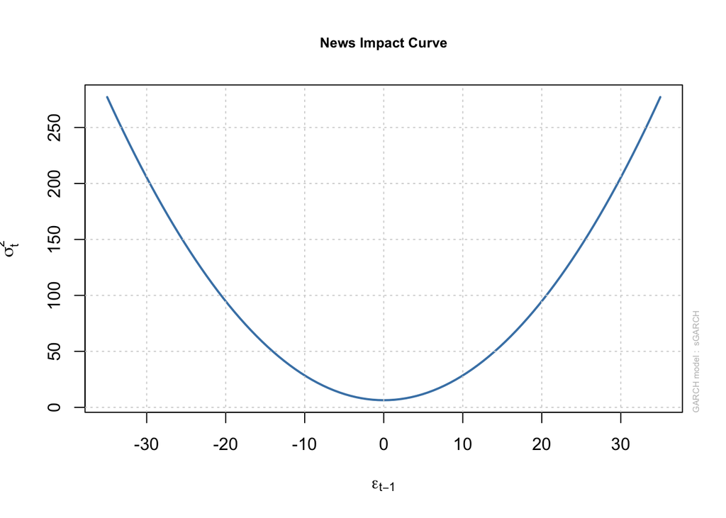

```r
plot(garch.fit, which = 12)
```

Now let’s try estimating the GJR-GARCH model discussed in the lecture. This simply requires us to set *model = “gjrGARCH”* in the **ugarchspec** function:

```r
garch.gjr.mod = ugarchspec(mean.model = list(armaOrder = c(2, 0), include.mean = TRUE),
                           variance.model = list(model = "gjrGARCH", garchOrder = c(1,1)),
                           distribution.model = "norm")

garch.gjr.fit = ugarchfit(spec=garch.gjr.mod,
                          data=aord,
                          solver = "hybrid",
                          solver.control = list(ftol_rel=1e-11,xtol_rel=1e-11, maxeval=10000))

garch.gjr.fit
```

```
##
## *---------------------------------*
## *          GARCH Model Fit        *
## *---------------------------------*
##
## Conditional Variance Dynamics
## -----------------------------------
## GARCH Model  : gjrGARCH(1,1)
## Mean Model   : ARFIMA(2,0,0)
## Distribution : norm
##
## Optimal Parameters
## ------------------------------------
##         Estimate  Std. Error  t value Pr(>|t|)
## mu      0.144857    0.045029  3.21699 0.001295
## ar1     0.023154    0.026940  0.85945 0.390091
## ar2     0.040663    0.025267  1.60934 0.107542
## omega   0.841527    0.140594  5.98552 0.000000
## alpha1  0.038538    0.025055  1.53817 0.124006
## beta1   0.564832    0.048153 11.72988 0.000000
## gamma1  0.474064    0.063804  7.42999 0.000000
##
## Robust Standard Errors:
##         Estimate  Std. Error  t value Pr(>|t|)
## mu      0.144857    0.044379  3.26410 0.001098
## ar1     0.023154    0.029717  0.77913 0.435903
## ar2     0.040663    0.027942  1.45529 0.145590
## omega   0.841527    0.464789  1.81056 0.070209
## alpha1  0.038538    0.033160  1.16218 0.245162
## beta1   0.564832    0.182325  3.09794 0.001949
## gamma1  0.474064    0.293294  1.61634 0.106020
##
## LogLikelihood : -3970.63
##
## Information Criteria
## ------------------------------------
##
## Akaike       4.1520
## Bayes        4.1723
## Shibata      4.1520
```

[output cut: 46 more lines]

```
## Negative Sign Bias  0.1789 0.8580
## Positive Sign Bias  0.3092 0.7572
## Joint Effect        0.7342 0.8651
##
##
## Adjusted Pearson Goodness-of-Fit Test:
## ------------------------------------
##   group statistic p-value(g-1)
## 1    20     55.86    1.716e-05
## 2    30     76.24    4.050e-06
## 3    40     84.54    3.299e-05
## 4    50    105.66    4.883e-06
##
##
## Elapsed time : 0.5082371
```

Once we have the fitted GJR-GARCH model, we can easily generate the empirical density of the standardized residuals as well as the news impact curve:

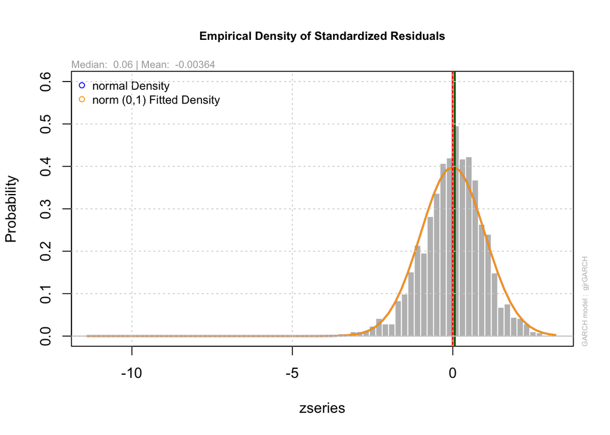

```r
plot(garch.gjr.fit, which = 8)
```

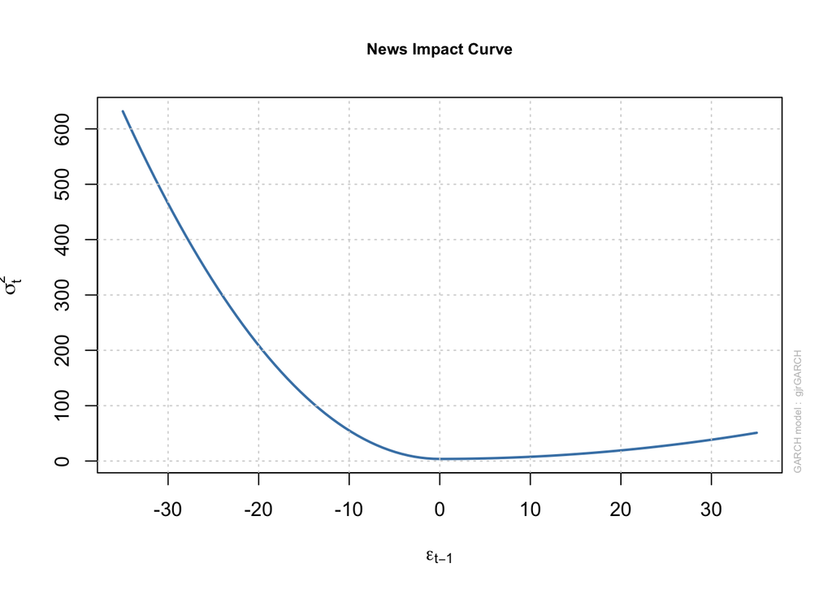

```r
plot(garch.gjr.fit, which = 12)
```

We can also change the distributional assumption of the innovations so that they follow a Student t distribution by setting *distribution.model = “std”*:

```r
garch.gjrt.mod = ugarchspec(mean.model = list(armaOrder = c(2, 0), include.mean = TRUE),
                           variance.model = list(model = "gjrGARCH", garchOrder = c(1,1)),
                           distribution.model = "std")

garch.gjrt.fit = ugarchfit(spec=garch.gjrt.mod,
                          data=aord,
                          solver = "hybrid",
                          solver.control = list(ftol_rel=1e-11,xtol_rel=1e-11, maxeval=10000))

garch.gjrt.fit
```

```
##
## *---------------------------------*
## *          GARCH Model Fit        *
## *---------------------------------*
##
## Conditional Variance Dynamics
## -----------------------------------
## GARCH Model  : gjrGARCH(1,1)
## Mean Model   : ARFIMA(2,0,0)
## Distribution : std
##
## Optimal Parameters
## ------------------------------------
##         Estimate  Std. Error  t value Pr(>|t|)
## mu      0.211954    0.042083   5.0366 0.000000
## ar1     0.029945    0.024247   1.2350 0.216829
## ar2     0.052642    0.023498   2.2403 0.025074
## omega   0.328837    0.092026   3.5733 0.000352
## alpha1  0.038651    0.023237   1.6633 0.096251
## beta1   0.793714    0.039912  19.8866 0.000000
## gamma1  0.152802    0.049847   3.0654 0.002174
## shape   7.307127    1.025730   7.1238 0.000000
##
## Robust Standard Errors:
##         Estimate  Std. Error  t value Pr(>|t|)
## mu      0.211954    0.042510   4.9859 0.000001
## ar1     0.029945    0.022780   1.3145 0.188665
## ar2     0.052642    0.019482   2.7021 0.006891
## omega   0.328837    0.148736   2.2109 0.027044
## alpha1  0.038651    0.024910   1.5516 0.120761
## beta1   0.793714    0.058873  13.4817 0.000000
## gamma1  0.152802    0.072868   2.0970 0.035997
## shape   7.307127    1.594081   4.5839 0.000005
##
## LogLikelihood : -3875.177
##
## Information Criteria
## ------------------------------------
##
## Akaike       4.0534
```

[output cut: 49 more lines]

```
## Negative Sign Bias  1.3386 0.1809
## Positive Sign Bias  0.2770 0.7818
## Joint Effect        4.7234 0.1932
##
##
## Adjusted Pearson Goodness-of-Fit Test:
## ------------------------------------
##   group statistic p-value(g-1)
## 1    20     22.35      0.26715
## 2    30     42.33      0.05244
## 3    40     39.99      0.42592
## 4    50     53.99      0.28954
##
##
## Elapsed time : 0.665062
```

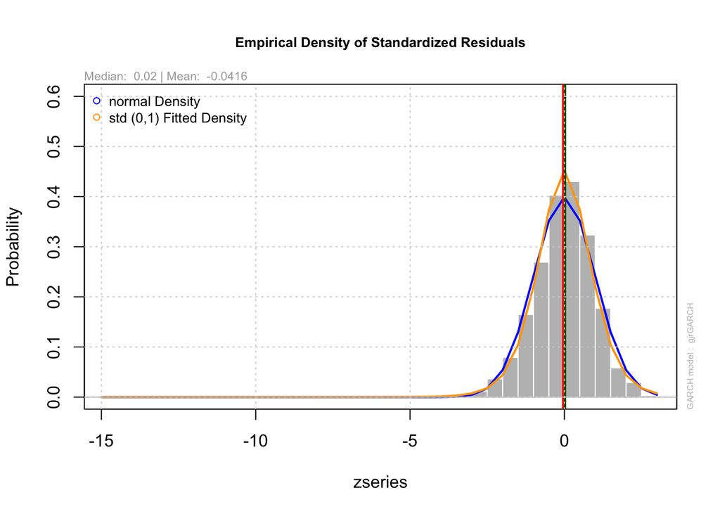

```r
plot(garch.gjrt.fit, which = 8)
```

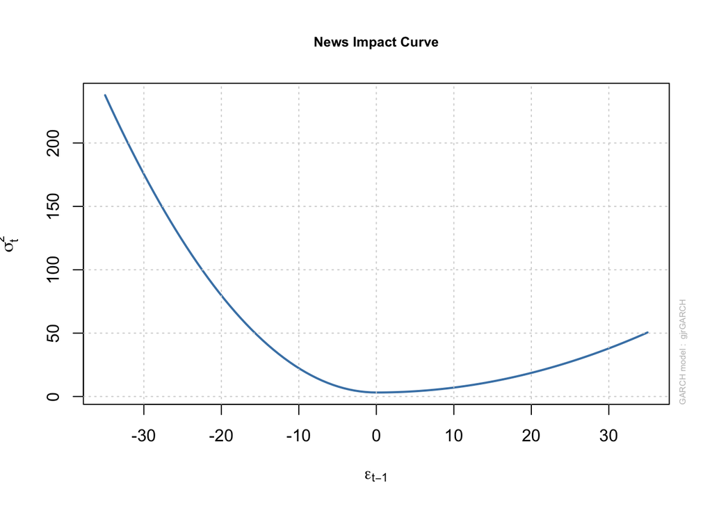

```r
plot(garch.gjrt.fit, which = 12)
```

Finally, to estimate the E-GARCH model discussed in the lecture, we simply set *model = “eGARCH”*

```r
garch.e.mod = ugarchspec(mean.model = list(armaOrder = c(2, 0), include.mean = TRUE),
                           variance.model = list(model = "eGARCH", garchOrder = c(1,1)),
                           distribution.model = "norm")

garch.e.fit = ugarchfit(spec=garch.e.mod,
                          data=aord,
                          solver = "hybrid",
                          solver.control = list(ftol_rel=1e-11,xtol_rel=1e-11, maxeval=10000))

garch.e.fit
```

```
##
## *---------------------------------*
## *          GARCH Model Fit        *
## *---------------------------------*
##
## Conditional Variance Dynamics
## -----------------------------------
## GARCH Model  : eGARCH(1,1)
## Mean Model   : ARFIMA(2,0,0)
## Distribution : norm
##
## Optimal Parameters
## ------------------------------------
##         Estimate  Std. Error  t value Pr(>|t|)
## mu      0.142005    0.032666   4.3472 0.000014
## ar1     0.026628    0.020514   1.2980 0.194284
## ar2     0.043969    0.016506   2.6638 0.007726
## omega   0.232626    0.036698   6.3389 0.000000
## alpha1 -0.214308    0.027053  -7.9217 0.000000
## beta1   0.834462    0.026555  31.4238 0.000000
## gamma1  0.323371    0.033841   9.5557 0.000000
##
## Robust Standard Errors:
##         Estimate  Std. Error  t value Pr(>|t|)
## mu      0.142005    0.022971   6.1819 0.000000
## ar1     0.026628    0.017280   1.5410 0.123324
## ar2     0.043969    0.010450   4.2076 0.000026
## omega   0.232626    0.121820   1.9096 0.056188
## alpha1 -0.214308    0.096608  -2.2183 0.026532
## beta1   0.834462    0.074999  11.1263 0.000000
## gamma1  0.323371    0.096817   3.3400 0.000838
##
## LogLikelihood : -3972.693
##
## Information Criteria
## ------------------------------------
##
## Akaike       4.1542
## Bayes        4.1745
## Shibata      4.1541
```

[output cut: 46 more lines]

```
## Negative Sign Bias 0.68987 0.4904
## Positive Sign Bias 0.36796 0.7129
## Joint Effect       1.21266 0.7500
##
##
## Adjusted Pearson Goodness-of-Fit Test:
## ------------------------------------
##   group statistic p-value(g-1)
## 1    20     52.91    4.822e-05
## 2    30     65.41    1.253e-04
## 3    40     80.12    1.159e-04
## 4    50     90.37    2.947e-04
##
##
## Elapsed time : 0.2530701
```

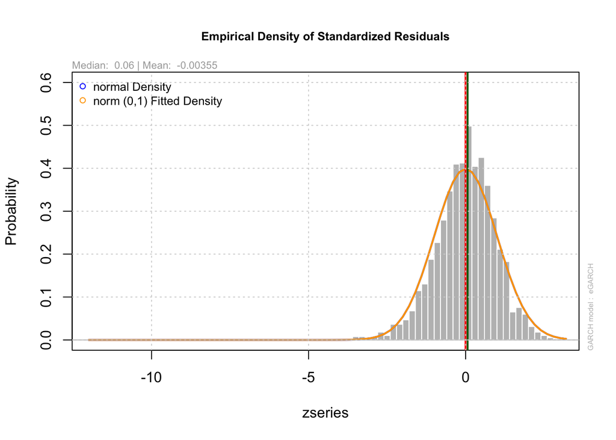

```r
plot(garch.e.fit, which = 8)
```

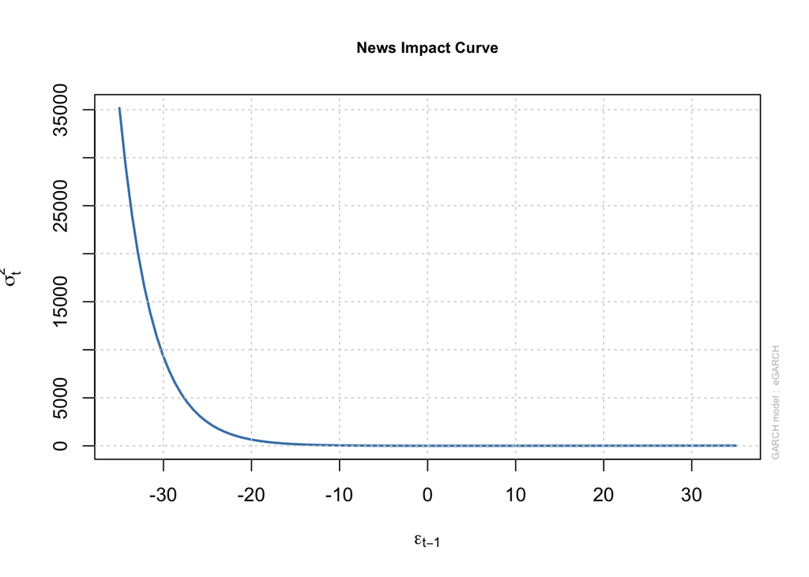

```r
plot(garch.e.fit, which = 12)
```